# Annual pension returns analysis

# PFA high risk (phr), 2011 - 2023

## QQ Plot

Skewed $t$-distribution (sstd):

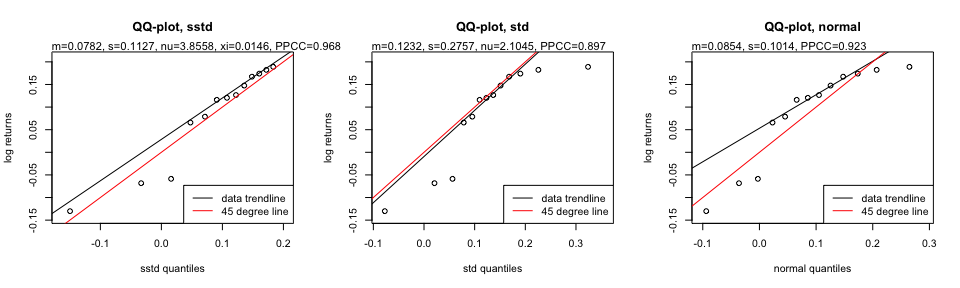

## Data vs fit

Let’s plot the fit and the observed returns together.

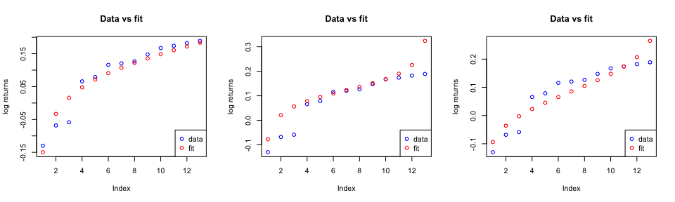

## Estimated distribution

Now lets look at the CDF of the estimated distribution for each 0.1% increment between 0.5% and 99.5% for the estimated distribution:

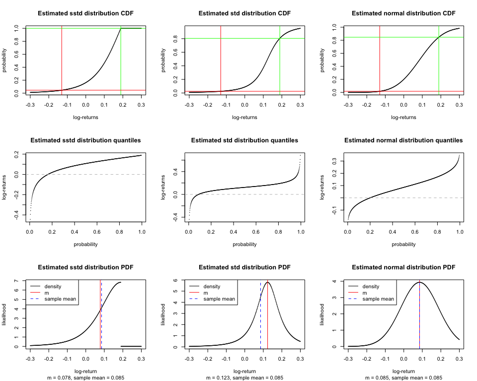

## Monte Carlo

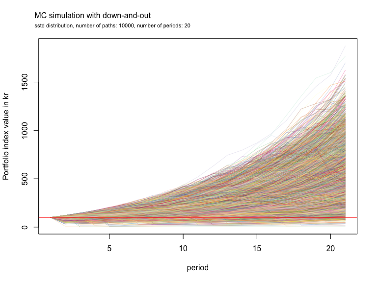

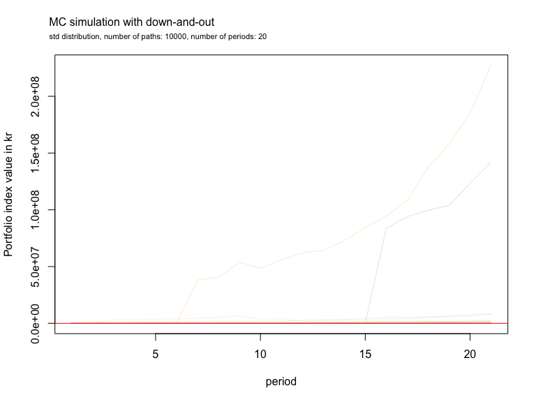

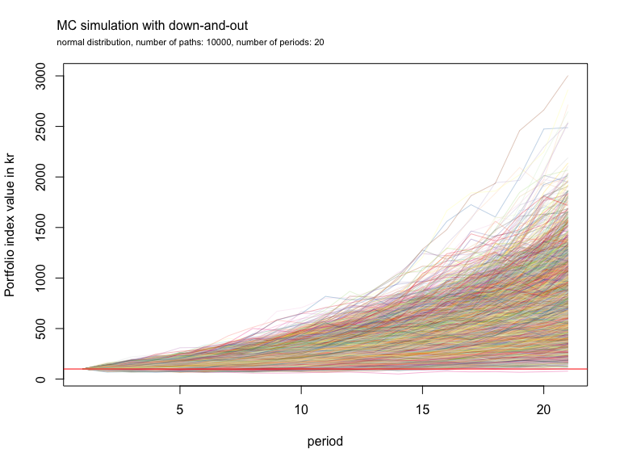

Sorted portfolio index values for last period of all runs

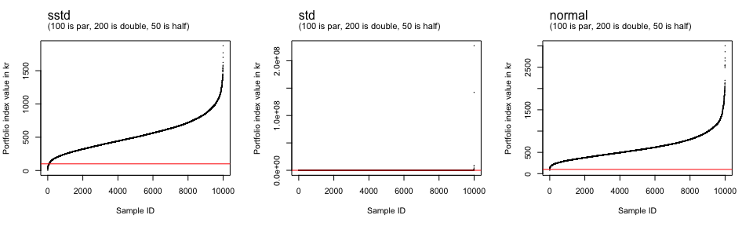

## Convergence

### Max vs sum

Max-vs-sum plots for the first four moments – a ratio that doesn’t fall toward zero flags that moment as possibly non-existent (see “Max-sum plots” in the comparison report for what this diagnostic tests). Panels by fitted distribution:

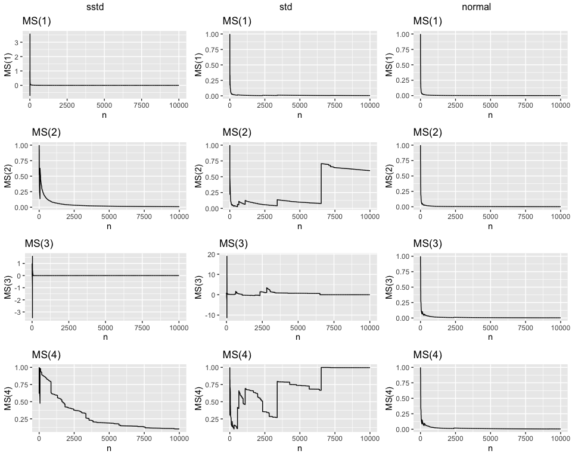

### MC

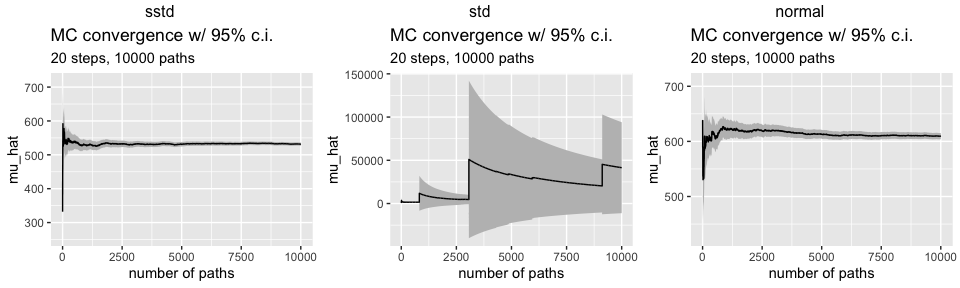

### IS

Skewed $t$-distribution with a normal proposal distribution.

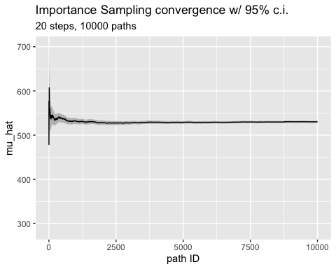

Parameters

```
## [1] 1.7723168 0.4503299
```

Objective function plots

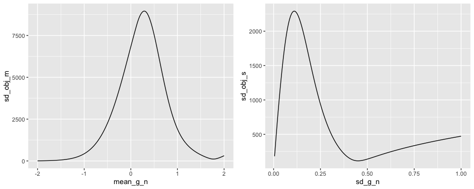

# Mix medium risk (mmr), 2011 - 2023

## QQ Plot

Skewed $t$-distribution (sstd):

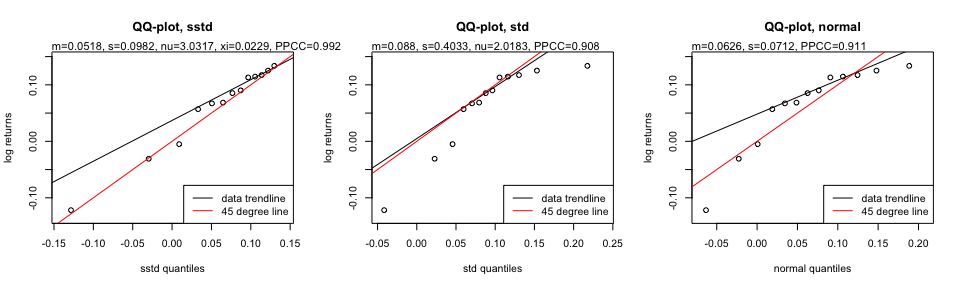

## Data vs fit

Let’s plot the fit and the observed returns together.

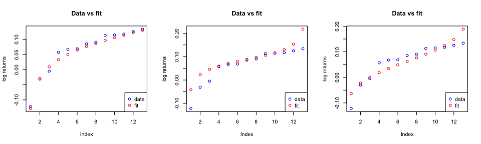

## Estimated distribution

Now lets look at the CDF of the estimated distribution for each 0.1% increment between 0.5% and 99.5% for the estimated distribution:

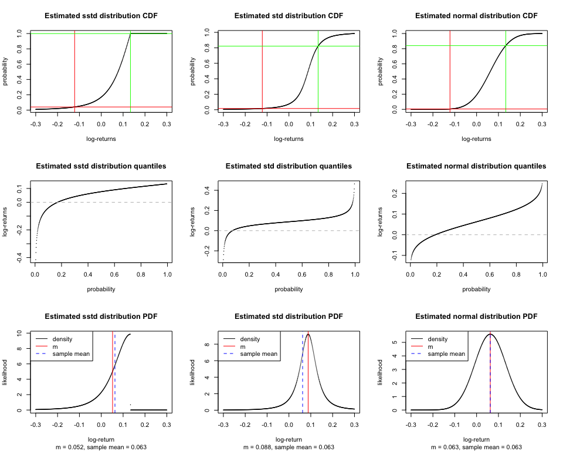

## Monte Carlo

Sorted portfolio index values for last period of all runs

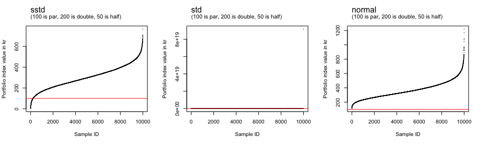

## Convergence

### Max vs sum

Max-vs-sum plots for the first four moments – a ratio that doesn’t fall toward zero flags that moment as possibly non-existent (see “Max-sum plots” in the comparison report for what this diagnostic tests). Panels by fitted distribution:

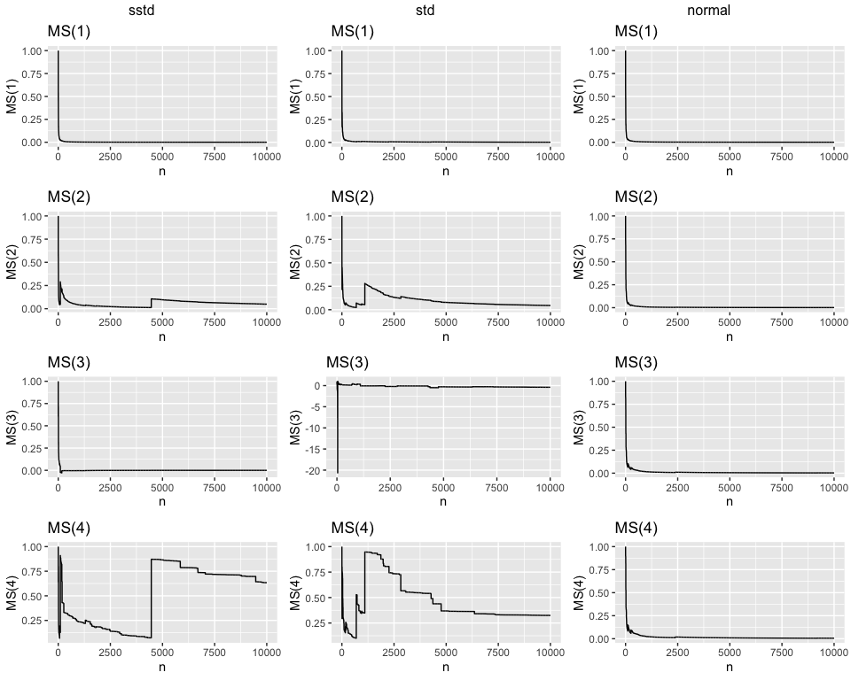

### MC

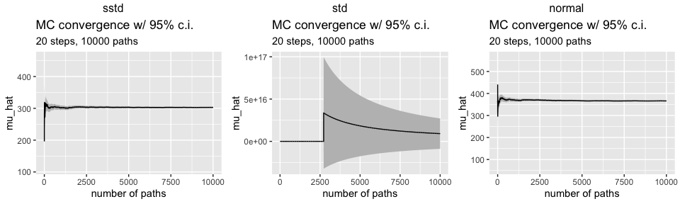

### IS

Skewed $t$-distribution with a normal proposal distribution.

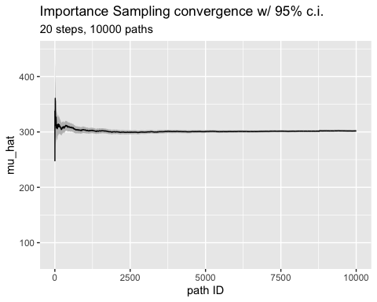

Parameters

```
## [1] 1.1788862 0.3716428
```

Objective function plots

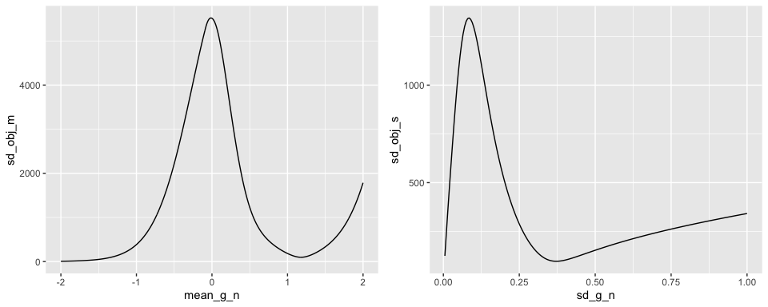

# Mix high risk (mhr), 2011 - 2023

## QQ Plot

Skewed $t$-distribution (sstd):

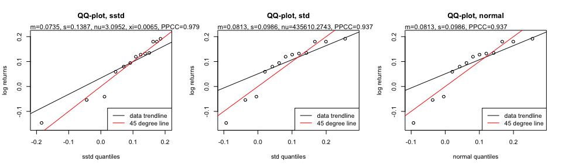

## Data vs fit

Let’s plot the fit and the observed returns together.

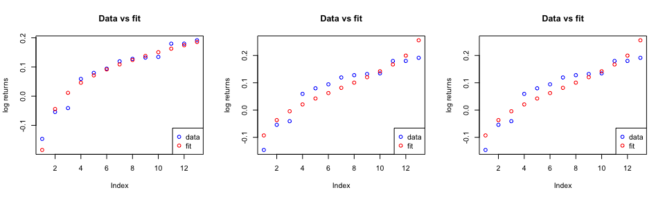

## Estimated distribution

Now lets look at the CDF of the estimated distribution for each 0.1% increment between 0.5% and 99.5% for the estimated distribution:

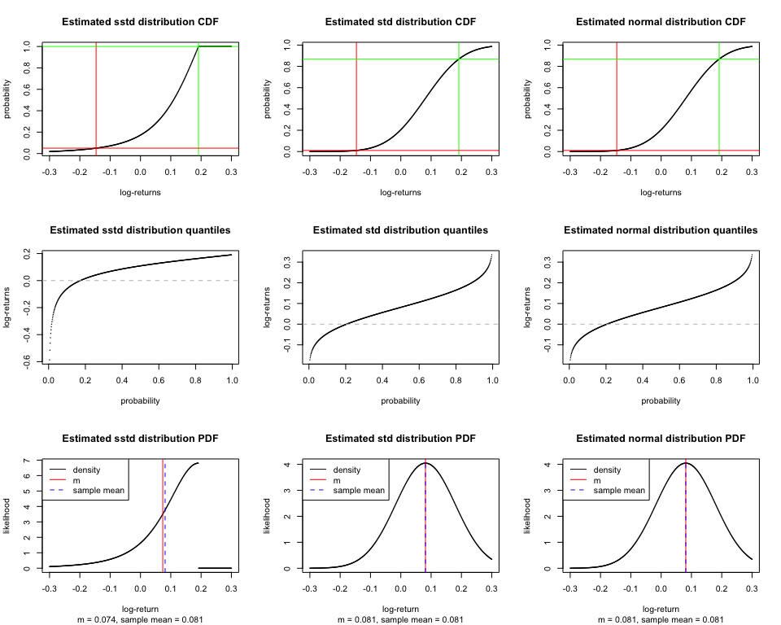

## Monte Carlo

Sorted portfolio index values for last period of all runs

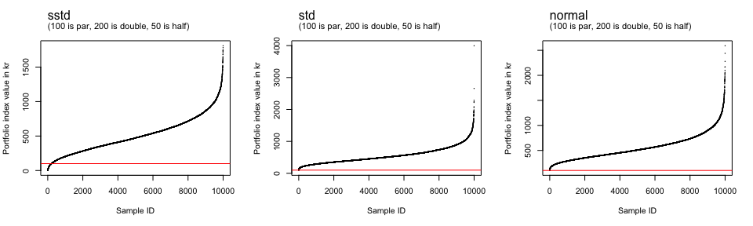

## Convergence

### Max vs sum

Max-vs-sum plots for the first four moments – a ratio that doesn’t fall toward zero flags that moment as possibly non-existent (see “Max-sum plots” in the comparison report for what this diagnostic tests). Panels by fitted distribution:

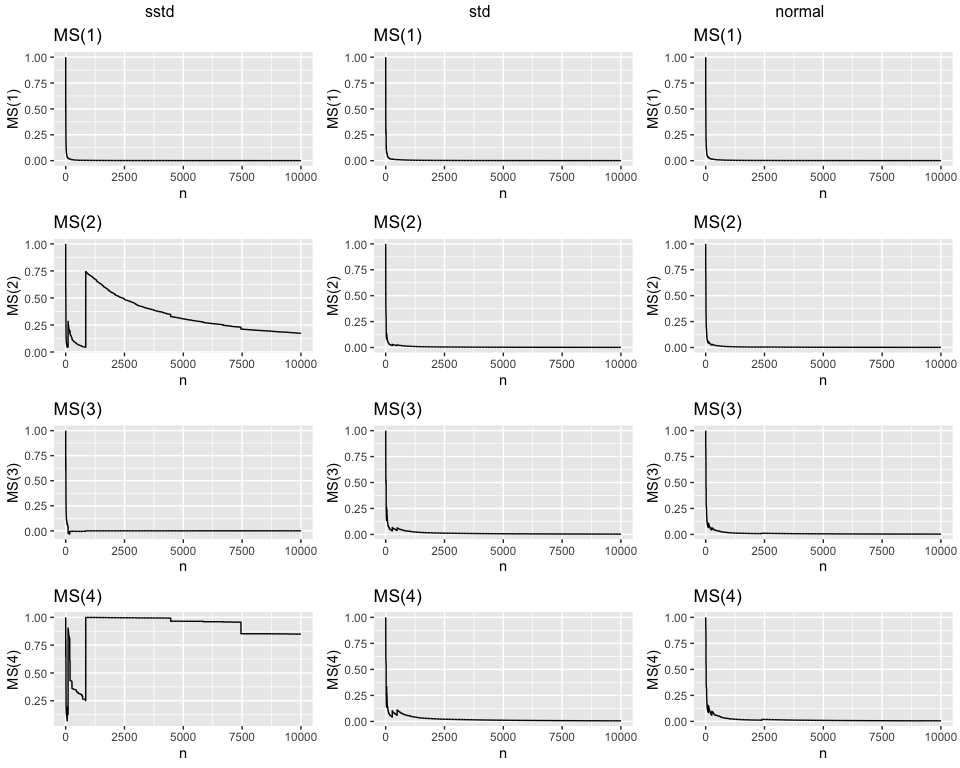

### MC

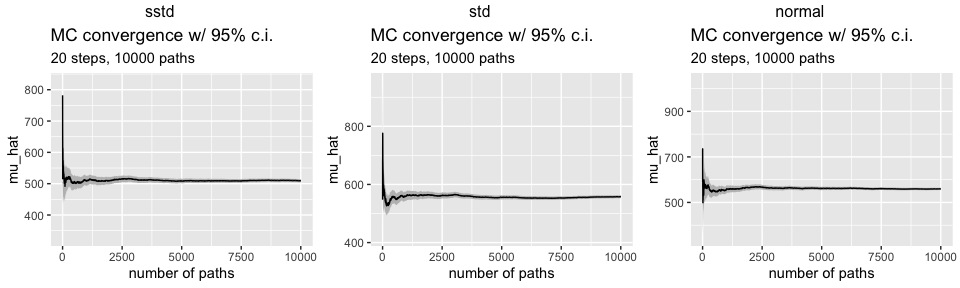

### IS

Skewed $t$-distribution with a normal proposal distribution.

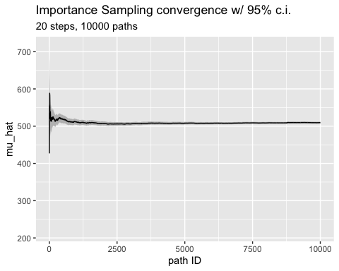

Parameters

```
## [1] 1.7626092 0.5077478
```

Objective function plots

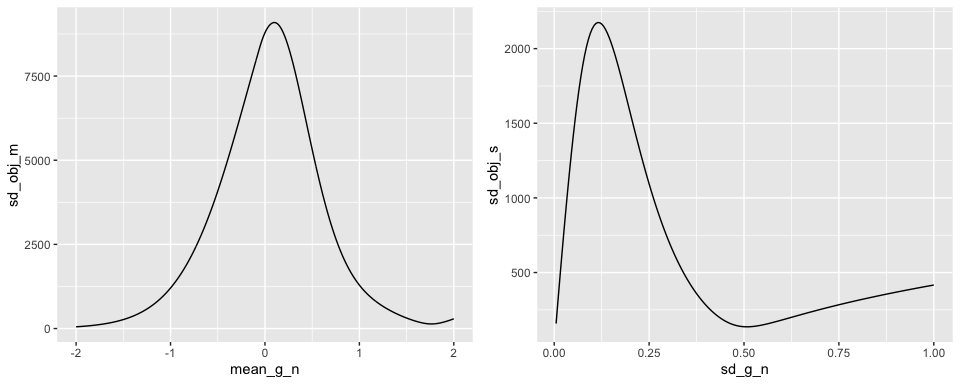

# Mix vmr+phr (vm_ph), 2011 - 2023

## QQ Plot

Skewed $t$-distribution (sstd):

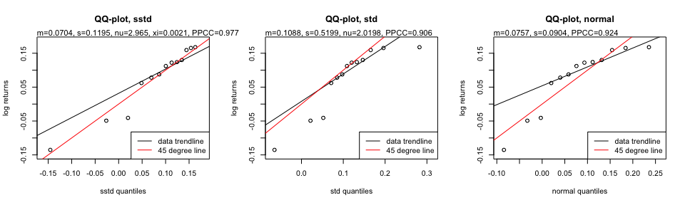

## Data vs fit

Let’s plot the fit and the observed returns together.

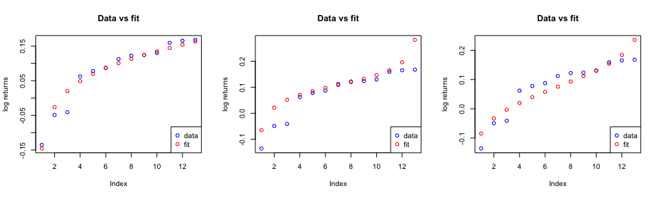

## Estimated distribution

Now lets look at the CDF of the estimated distribution for each 0.1% increment between 0.5% and 99.5% for the estimated distribution:

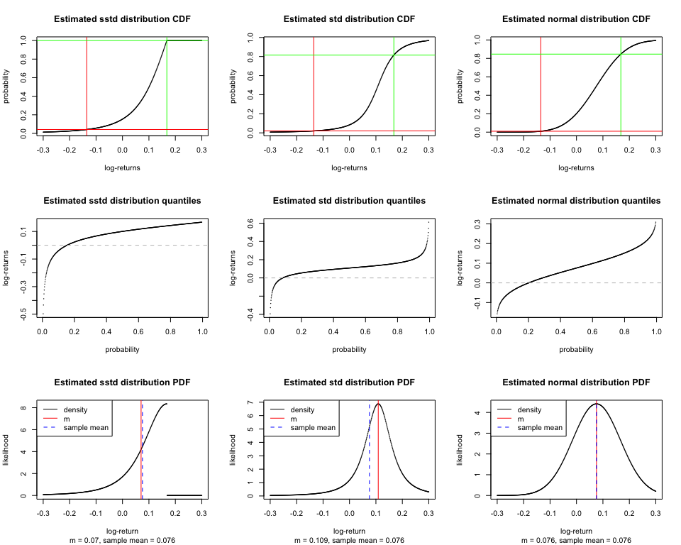

## Monte Carlo

Sorted portfolio index values for last period of all runs

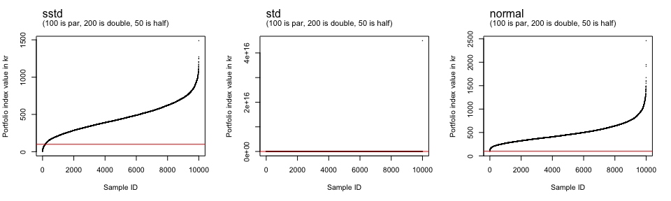

## Convergence

### Max vs sum

Max-vs-sum plots for the first four moments – a ratio that doesn’t fall toward zero flags that moment as possibly non-existent (see “Max-sum plots” in the comparison report for what this diagnostic tests). Panels by fitted distribution:

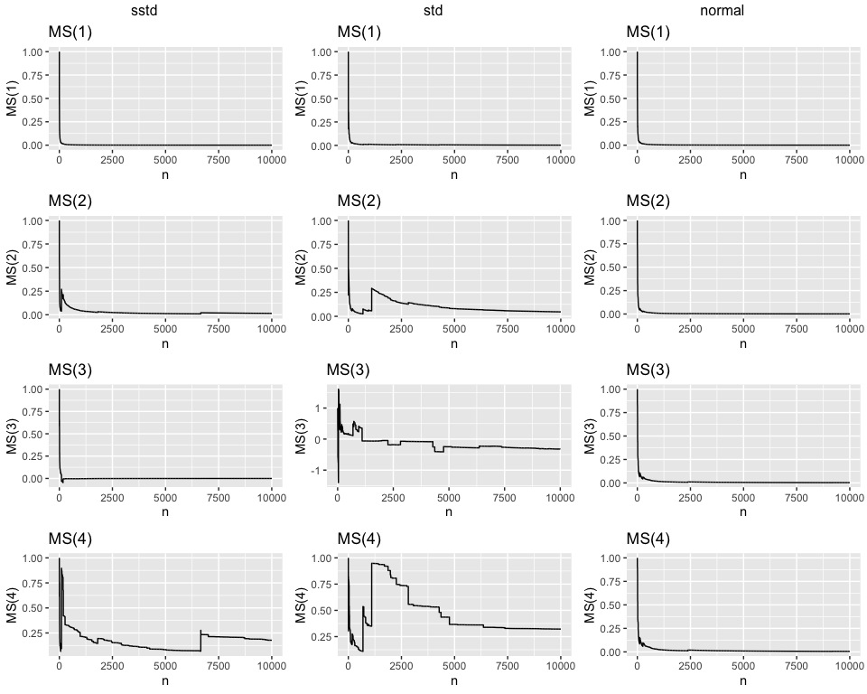

### MC

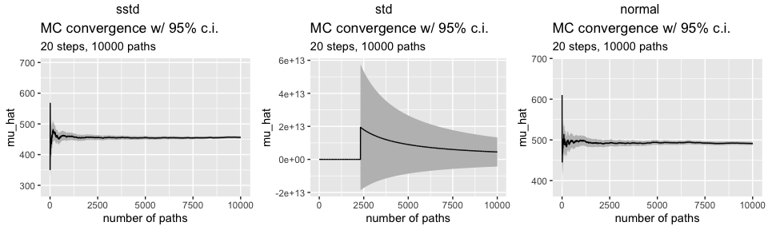

### IS

Skewed $t$-distribution with a normal proposal distribution.

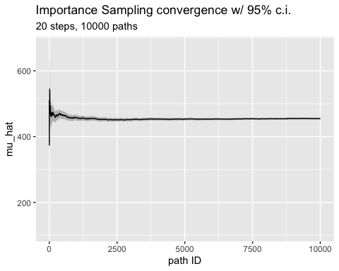

Parameters

```
## [1] 1.6160234 0.4361716
```

Objective function plots

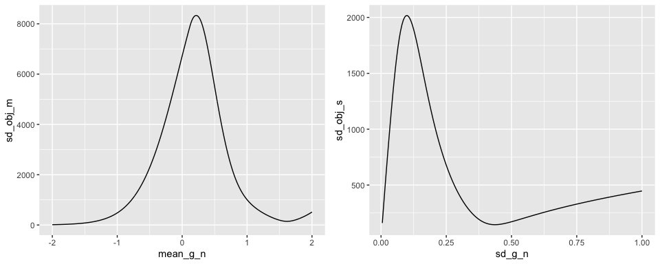

# Mix vhr+pmr (mh_pm), 2011 - 2023

## QQ Plot

Skewed $t$-distribution (sstd):

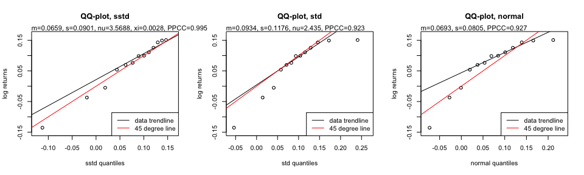

## Data vs fit

Let’s plot the fit and the observed returns together.

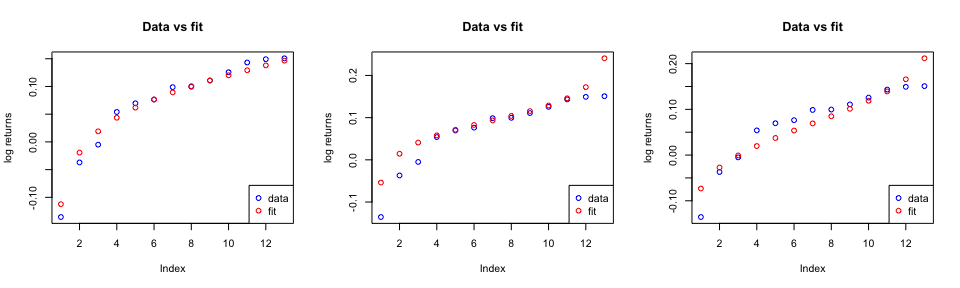

## Estimated distribution

Now lets look at the CDF of the estimated distribution for each 0.1% increment between 0.5% and 99.5% for the estimated distribution:

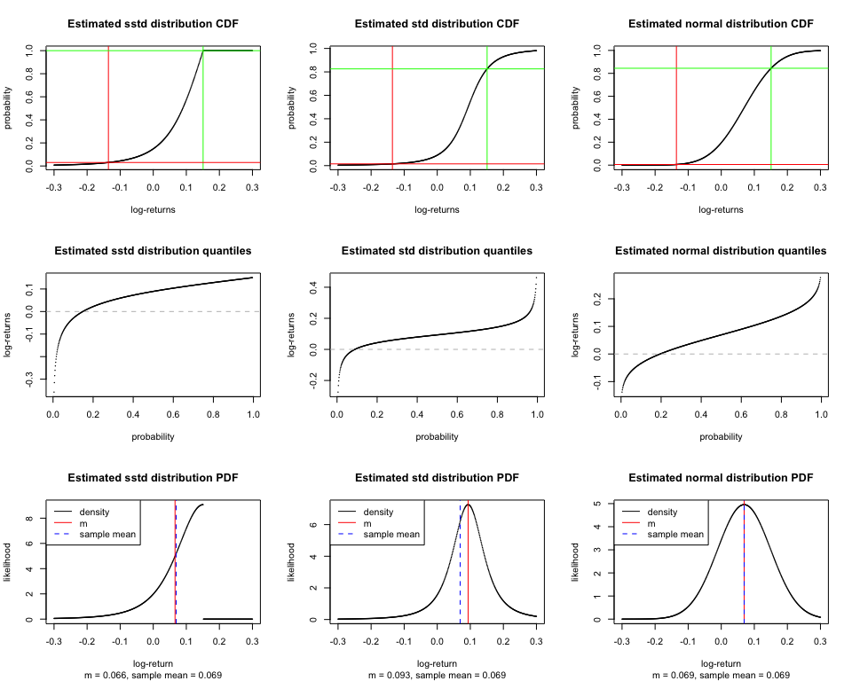

## Monte Carlo

Sorted portfolio index values for last period of all runs

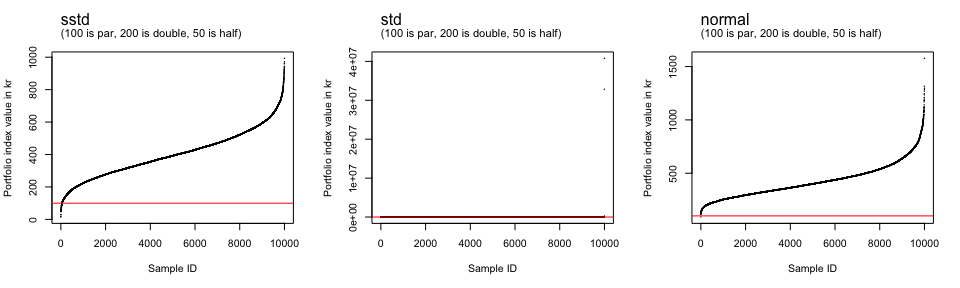

## Convergence

### Max vs sum

Max-vs-sum plots for the first four moments – a ratio that doesn’t fall toward zero flags that moment as possibly non-existent (see “Max-sum plots” in the comparison report for what this diagnostic tests). Panels by fitted distribution:

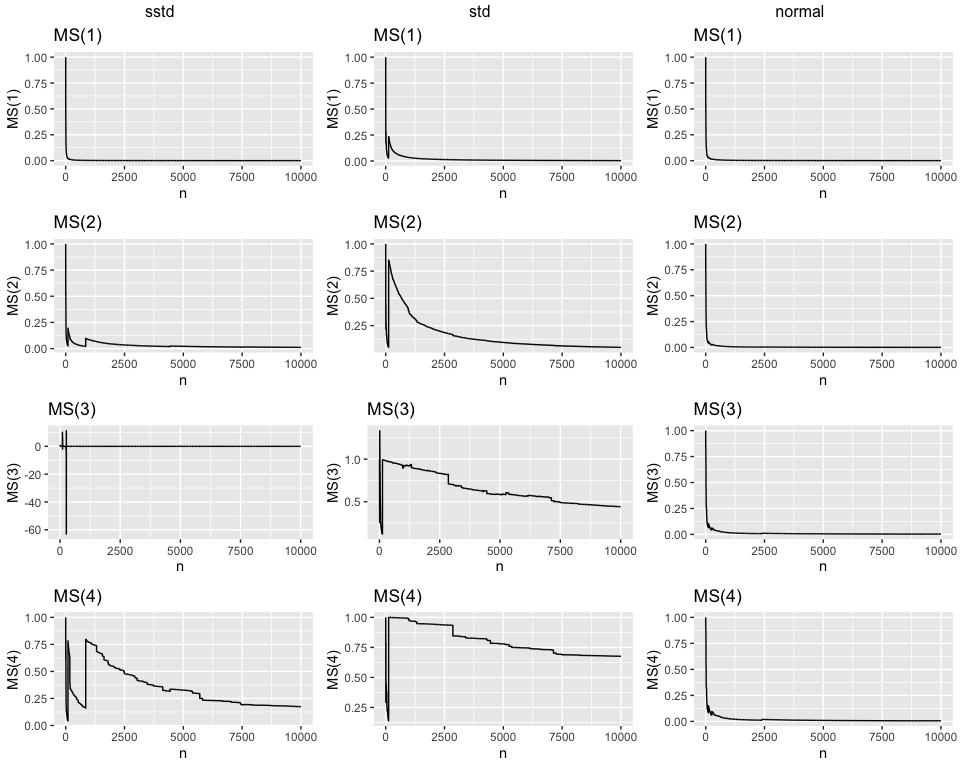

### MC

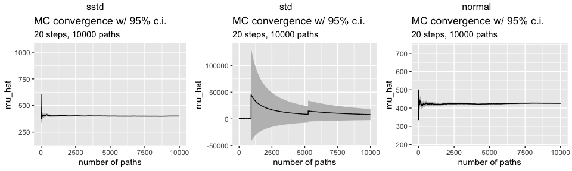

### IS

Skewed $t$-distribution with a normal proposal distribution.

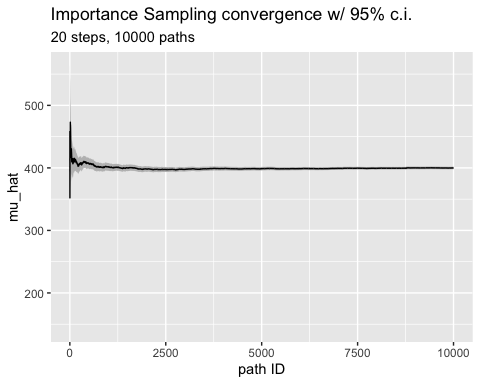

Parameters

```
## [1] 1.4560560 0.3635845
```

Objective function plots

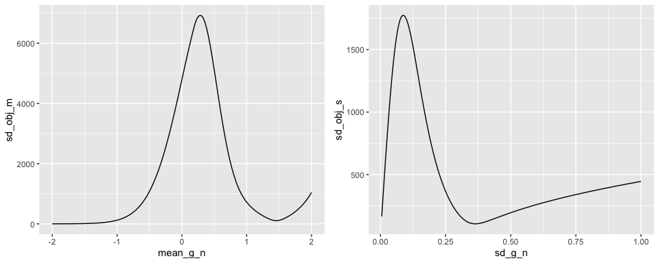